# CADEIAS DE MARKOV - TRABALHO 1

Willian Meira Schlichta - GRR20159077

5 de agosto de 2020

**Exercício 01**.Uma matriz de transição para o número de linhas telefónicas ocupadas. Suponha que o número de linhas usadas nos tempos 1, 2, … formem uma Cadeia de Markov com matriz de probabilidades de transição estacionária. Essa cadeia possui seis estados possíveis 0, 1, …, 5, onde $i$ é o estado no qual exatamente $i$ linhas estão sendo usadas em um determinado momento (i=0,1,⋯,5). Suponha que a matriz de transição Γ seja a seguinte:

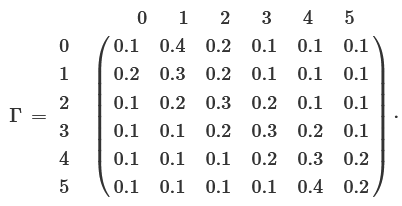

1. Supondo que todas as cinco linhas estejam em uso em um determinado momento de observação, determinar a probabilidade de que exatamente quatro linhas serão usadas no próximo tempo de observação.

   $P(C_{n+1}=4/C_{n}=5) = 0,4 = 40%$
2. Supondo que nenhuma linha esteja em uso em um determinado momento, determinar a probabilidade de que pelo menos uma linha esteja em uso no próximo momento de observação.

   $P(C_{n+1}\geqslant 1/C_{n}=0) = 0,4 +0,2 +0,1 +0,1 +0,1 = 0,9 = 90%$

**Exercício 02**. Mostre que o seguinte processo auto-regressivo é um processo Markov: $Cn=ρC_{n−1}+ξ_n$, e $C_0=0$, onde $ξ_1,⋯,ξ_n$ são variáveis aleatórias independentes e igualmente distribuídas.

$C_{0} = 0$

$C_{n}=PC_{n-1}+\epsilon_{n}$ onde $\epsilon_{n}$ são variáveis aleatórias $iid$

$P(C_{n+1}=cn+1/C_{n}=cn)=P(PC_{n}+\epsilon_{n+1}=cn+1)PC_{n-1}+\epsilon_{n}=C_{n})$

$PC_{n}+\epsilon_{n+1}=cn+1 \rightarrow \epsilon_{n+1}=cn+1 - PC_{n}$

De $P(C_{n}=cn/C_1=c1, C_2=c_2,C_n=cn)$

Observamos que:

$C1=c1 \rightarrow \epsilon_{1}=C1-PC_{0}=C1$ $C2=c2 \rightarrow \epsilon_{2}=C2-PC_{1}$ $C3=c3 \rightarrow \epsilon_{3}=C3-PC_{2}$

$Cn=cn \rightarrow \epsilon_{n}=Cn-PC_{n-1}$

Então:

$P(\epsilon_{n+1}=C_{n+1}-P_{cn}/\epsilon_{1}=C_{1},\cdots , \epsilon_{n}=cn-P_{c}-1)$

Como as variáveis $\epsilon_{n}$ são independentes, a equação acima pode reescrita como:

$P(\epsilon_{n+1}=cn+1 - P_{cn})$

Como $\epsilon_{n}$ dependem somente do instante anterior, é uma cadeia de Markov

**Exercício 05**. Seja {$\bar{C_n}$} a sequência de médias amostrais calculadas a partir de $C1,C2,⋯$, uma sequência de variáveis aleatórias independentes e identicamente distribuídas, isto é, $\bar{C_n}=\frac{1}{n}(C_1+C_2+⋯+C_n)$⋅

1. É {$\bar{C_n}$} um processo de Markov?

Sim.

${\delta }= {\delta}'$

*${\delta }= (n+1) \bar{C}_{n+1}-n\bar{C}n$

**${\delta}'=(n+1) \bar{C}_{n+1}-\sum_{k=1}^{n}C_{k}$

em que $\sum_{k=1}^{n}C_{k}=n\bar{C}n$

Com isso temos que:

$(n+1) \bar{C}_{n+1}-n\bar{C}n=(n+1)\bar{C}_{n+1} - \sum_{k=1}^{n}C_{k}$

$(n+1) \bar{C}_{n+1}-n\bar{C}n=(n+1) \bar{C}_{n+1}-n\bar{C}n$

Logo temos que:

${\delta }= {\delta}'$

2. Se a resposta à primeira parte é sim, encontrar a probabilidade de transição $P(\bar{C}_{n+1}=y|\bar{C}_{n−1}=x)$.

$\gamma_{xy} = P(\overline{C}_{n}=y/\overline{C}_{n-1}=x) = \frac{P([\overline{C}_{n}=y]\bigcap P([\overline{C}_{n-1}=x]}{P(\overline{C}_{n-1}=x)}$

dado que $\overline{C}_{n}=\frac{1}{n}(\sum_{i=1}^{n}C_{i})$ temos:

$\overline{C}_{n-1}=\frac{1}{n}(\sum_{i=1}^{n}C_{i})=x \rightarrow \sum_{i=1}^{n}C_{i}=(n-1)x$

$\overline{C}_{n}=\frac{1}{n}(\sum_{1=1}^{n}C_{i}) \rightarrow \frac{1}{n}(C_{n}+\sum_{i=1}^{n-1}C_{i})$

Então:

$\frac{P([\frac{1}{n}(C_{n}+\sum_{i=1}^{n-1}C_{i})=y]\bigcap[\frac{1}{n}(\sum_{i=1}^{n-1}C_{i})=x])}{P(\frac{1}{n}(\sum_{i=1}^{n-1}C_{i})=x)}$

$\frac{P([\frac{1}{n}(C_{n}+(n-1)x)=y]\bigcap [\frac{1}{n}(\sum_{i=1}^{n-1}C_{i})=x])}{P(\frac{1}{n}(\sum_{i=1}^{n-1}C_{i})=x)}$

$\frac{P([C_{n}=ny-(n-1)x]\bigcap [\frac{1}{n}(\sum_{i=1}^{n-1}C_{i})=x])}{P(\frac{1}{n}(\sum_{i=1}^{n-1}C_{i})=x)}$

sendo $iid$

$\frac{P([C_{n}=ny-(n-1)x].P(\frac{1}{n}(\sum_{i=1}^{n-1}C_{i})=x)}{P(\frac{1}{n}(\sum_{i=1}^{n-1}C_{i})=x)}$

$P(C_{n+1}=y =ny-(n-1)x)$

**Exercício 19**. Seja {$C_n:n≥0$} uma Cadeia de Markov. Mostre que $P(C_0=c+0|C_1=c_1,⋯,C_n=c_n)=P(C_0=c_0|C_1=c_1)$⋅

Para demonstrar, utilizaremos a notação de probabilidade condicional:

$$P(A_{3}|A_{1}\cap A_{2})=P(A_{3}|A_{2})$$
$$P(A_{3}|A_{1}\cap A_{2})=\frac{P(A_{1}\cap A_{2} \cap A_{3})}{P(A_{1}\cap A_{2})}$$
$$=\frac{P(A_{1}\cap A_{3}|A_{2})P(A_{1})}{P(A_{1}\cap A_{2})}$$
$$=\frac{P(A_{3}|A_{2})P(A_{1}A_{2})P(A_{2})}{P(A_{1}\cap A_{2})}$$
$$=\frac{P(A_{3}|A_{2})P(A_{1}\cap A_{2})}{P(A_{1}\cap A_{2})}$$
$$=P(A_{3}|A_{2})$$
Ou seja, se dado o estado atual, os estados passados não tem influencia sobre o futuro.